# Mice case study 1

In this case study, we are going to analyse a dataset containing bodyweight measurements of mice receiving two different diets, the standard “chow” diet and a high-fat diet. We also have the gender of the mice, but we will save that variable for next case study. Our hypothesis is that the high-fat diet has an effect on the weight of the mice.

These case studies will all follow more or less the same structure:

- Read the data into R
- Tidy the data with `tibble` and `dplyr`
- Plot the data with `ggplot2`
- Fit models to the data

Although we don’t need to tidy this dataset.

First, we install some packages we will need, if we don’t have them installed already. The “tidyverse” package installs several packages in the “tidyverse” ecosystem, including “tibble”, “readr” and “ggplot2”.

```r
install.packages('tidyverse')  # Installs several packages from the tidyverse ecosystem.
install.packages('magrittr')
install.packages('devtools')
```

Next, we load the packages we need.

```r
library(tibble)  # The "tibble" datastructure.
library(dplyr)  # Working with the tibble datastructure.
library(ggplot2)  # Plotting.
library(magrittr)  # Need this for the %>% (pipe) operator.
library(devtools)  # For printing the session info at the end of the notebook.
```

# Read and pre-process data

The data we need is available on the web, so we are just going to download it directly to our working directory with an R command. The `download.file()` function takes an URL, downloads the file that URL points to, and saves it in the current directory with the file name we specify.

```r
# Download CSV file into current directory.
url = 'https://raw.githubusercontent.com/genomicsclass/dagdata/master/inst/extdata/mice_pheno.csv'
download.file(url, 'mice_pheno.csv')
```

We read the data from the CSV file we just downloaded. Below, we pass the relative path to the `read_csv()` function; in this case, the file is in our current working directory.

```r
# Read CSV file into a tibble.
mice = read_csv('mice_pheno.csv')
```

The `read_csv()` function reads the CSV file and stores the data in a tibble object which we name `mice`. The data is stored in the memory of the computer, and any changes made to `data` are only stored in memory. If you want to save the changes you make to the data, write the data to disk using, for example, the `write_csv()` function.

Below, we use the `head()` function to inspect the first few rows of the data. We also see the column names (such as “Sex” and “Diet”) and the data type (such as `<chr>` and `<dbl>`).

```r
head(mice)
```

| Sex | Diet | Bodyweight |
| --- | --- | --- |
| F | hf | 31.94 |
| F | hf | 32.48 |
| F | hf | 22.82 |
| F | hf | 19.92 |
| F | hf | 32.22 |
| F | hf | 27.50 |

Because we are lazy, we are going to simplify the column names a bit, as we are going to be writing these a lot. We do this using the `rename()` function. Note that we could use the syntax `rename(mice, "new variable name" = "old variable name")`, but instead we are using the syntax `mice %>% rename("new variable name" = "old variable name")`, where `%>%` is the *pipe* operator from the `magrittr` package.

```r
# Change column names.
mice = mice %>% rename('sex' = 'Sex', 'diet' = 'Diet', 'weight' = 'Bodyweight')
```

We are not going to use all of the columns in the data, so we drop all the unused columns. We do this using the `select()` function, supplying the names of the columns we want to retain.

```r
# Subset the columns in the data.
mice = mice %>% select("diet", "weight")
```

We print the head of the dataset again, just to show that changes have been made.

```r
head(mice)
```

| diet | weight |
| --- | --- |
| hf | 31.94 |
| hf | 32.48 |
| hf | 22.82 |
| hf | 19.92 |
| hf | 32.22 |
| hf | 27.50 |

# Exploratory data analysis

In this section, we will visualize the data, in order to get an overview of the data, check assumptions, and possibly pre-process the data further if necessary. For this first case study, we will make a histogram, a box plot and a QQ-plot of each of our variables.

First, however, let’s quickly look at some summary stats for the data, using the `summary()` function. Note that the `weight` variable has five `NA` values, meaning that there is missing data.

```r
summary(mice)
```

```
     diet               weight
 Length:846         Min.   :15.51
 Class :character   1st Qu.:24.04
 Mode  :character   Median :28.19
                    Mean   :28.85
                    3rd Qu.:32.95
                    Max.   :54.08
                    NA's   :5
```

`summary()` didn’t reveal much about our categorical variable, `diet`. Below we use the `table()` function to get counts of each distinct value of `diet`. Note that we again use `select()` to get the variable we’re interested in.

```r
mice %>% select(diet) %>% table()
```

```
.
chow   hf
 449  397
```

We use `ggplot2` to plot our data. The `ggplot(mice, aes(weight))` statement below tells R that we want to plot the `weight` variable in the `mice` dataset. Then we further say that we want to make a histogram out of this data with 15 bins. We make a title for the plot as well. Note that we simply “add” more functionality on top of the plot with the `+` operator. `ggplot2` will not know how to deal with the NA values, and will give us a warning if we pass it NA values. To ignore this warning we use the `na.rm=TRUE` argument.

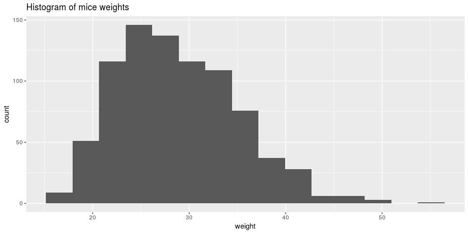

```r
ggplot(mice, aes(weight)) +
  geom_histogram(na.rm=TRUE, bins=15) +
  labs(title='Histogram of mice weights')
```

Actually, we aren’t interested in the distribution of mice weights in general. What we are interested in is the two populations, or groups, receiving the chow and high-fat diets. There are many ways we could split this into two plots. Below, we’ve decided to do it using the `facet_grid()` function, receiving a variable name with which to split the data. We will discuss the `~` operator when we get to the modelling part, later in this case study.

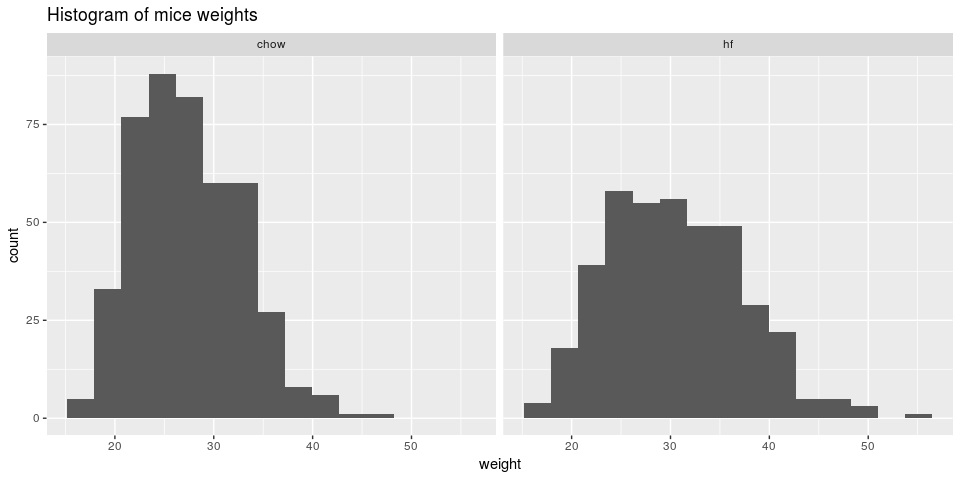

```r
ggplot(mice, aes(weight)) +
  geom_histogram(na.rm=TRUE, bins=15) +
  labs(title='Histogram of mice weights') +
  facet_grid(~ diet)
```

`geom_boxplot()` will split the data according to the `x` variable, so there is no need to use `facet_grid()` below.

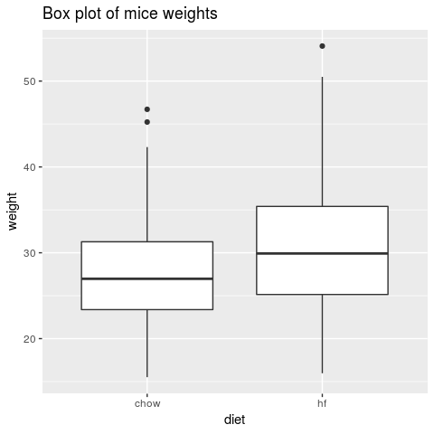

```r
ggplot(mice, aes(x=diet, weight)) +
  geom_boxplot(na.rm=TRUE) +
  labs(title='Box plot of mice weights')
```

Next, we are going to make QQ-plots of our variables. The QQ-plot is a good way to check whether data is normally distributed. It computes theoretical quantiles based on summary statistics of the data and assuming it is normally distributed, and then compares these with the actual quantiles. The closer the points match the QQ-line, the more accurately the normal distribution represents the data.

Below we use `stat_qq()` to add the points, representing the theoretical and actual (“sample”) quantiles, and `stat_qq_line()` to add the QQ-line, ignoring NA values with `na.rm=TRUE`. Note that we pass the variable to `ggplot()` as `aes(sample=weight)` this time, as the `stat_qq()` and `stat_qq_line()` functions will look in this keyword for the data.

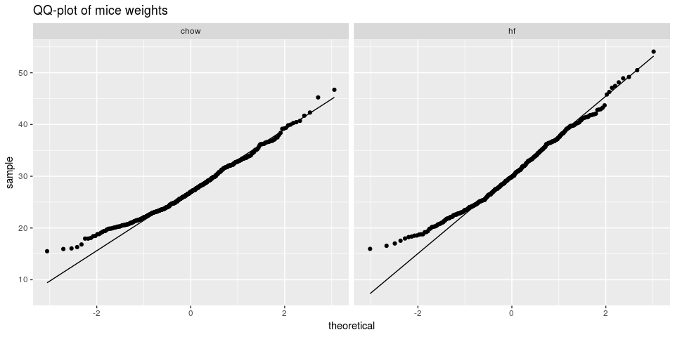

```r
ggplot(mice, aes(sample=weight)) +
  stat_qq(na.rm=TRUE) + stat_qq_line(na.rm=TRUE) +
  labs(title='QQ-plot of mice weights') +
  facet_grid(~ diet)
```

# Modelling

Below, we use a t test to test the difference in the mean `weight` in two groups, the `chow` and the `hf` groups, specifying the `mice` dataset. The `weight ~ diet` syntax, using the `~` operator, is common in modelling in R. This is a formula relating the variable of interest (the reponse) on the left-hand-side (in this case `weight`) to the explanatory variables on the right-hand-side. This way of thinking about it will make more sense when we get to the linear models, in the next case study.

```r
model = t.test(weight ~ diet, data=mice)
model
```

```
    Welch Two Sample t-test

data:  weight by diet
t = -7.1932, df = 735.02, p-value = 1.563e-12
alternative hypothesis: true difference in means is not equal to 0
95 percent confidence interval:
 -3.906857 -2.231533
sample estimates:
mean in group chow   mean in group hf
          27.41281           30.48201
```

We see that the test is highly significant. The 95% confidence interval for the difference in mean is somewhat broad if what we wanted was a precise estimate of this difference. However, if we just want to know whether there *is* a difference, what we can note is that the confidence interval does not include zero, not by far. So we can be quite confident that this difference is real, provided that the original experiment sampled the populations correctly.